# INFX 576: Problem Set 1 - Basic Concepts and Network Data

Harkar Talwar

Due: Friday, April 6, 2018

##### Collaborators: Prateek Tripathi

##### Instructions:

Before beginning this assignment, please ensure you have access to R and RStudio.

1. Download the `problemset1.Rmd` file from Canvas. Open `problemset1.Rmd` in RStudio and supply your solutions to the assignment by editing `problemset1.Rmd`. You will also need the `problemset1_data.Rdata` file which contains the network datasets needed for this assignment.
2. Replace the “Insert Your Name Here” text in the `author:` field with your own full name. Any collaborators must be listed on the top of your assignment.
3. Be sure to include well-documented (e.g. commented) code chucks, figures and clearly written text chunk explanations as necessary. Any figures should be clearly labeled and appropriately referenced within the text.
4. Collaboration on problem sets is acceptable, and even encouraged, but each student must turn in an individual write-up in his or her own words and his or her own work. The names of all collaborators must be listed on each assignment. Do not copy-and-paste from other students’ responses or code.
5. When you have completed the assignment and have **checked** that your code both runs in the Console and knits correctly when you click `Knit PDF`, rename the R Markdown file to `YourLastName_YourFirstName_ps1.Rmd`, knit a PDF and submit the PDF file on Canvas.

##### Setup:

In this problem set you will need, at minimum, the following R packages.

```r
# Load standard libraries
library(statnet)

# Load data
load("problemset1_data.Rdata")
ls() # Print objects in workspace to see what is available
```

```
## [1] "sw.incidence"
```

#### Problem 1: Manipulating Network Data

Consider the follow question for eliciting social relationships: ``Who have you talked to about important matters within the last 48 hours.’’ Following the steps outlined below, import this data into R and make a visualization of your egocentric network.

- Write down a response to this question.  
  *I’ve talked to 5 persons about important matters within the last 48 hours. They belong to two categories, friends and family. Among my friends are two individuals, Sahil and Prateek. In my family, I spoke with my dad, mom and sister.*
- Consider the induced network among the people who have talked to about important matters. Estimate (use your best guess) the relationships between each pair of individuals.  
  *I’ve estimated several relationships between my alters. In my family, my mom, dad and sister, all speak to each other on important matters. Further, as per my knowledge, both my friends, Sahil and Prateek also talk to each other on important matters. There are however no ties between my family and friend sub-groups.*
- Organize your data into a spreadsheet using your favorite editor. Save your network data as a CSV. Import the data into R and make a visualization of your network.

```r
# Read the adjacency matrix of the egocentric network from a CSV file
csv.matrix <- read.csv("EgoCentricNetwork.csv", header = TRUE, row.names = 1, check.names = FALSE)
print(csv.matrix)
```

```
##         Harkar Friend_Sahil Friend_Prateek Family_ Dad Family_Mom
## Harkar       0            1              1           1          1
## Sahil        1            0              1           0          0
## Prateek      1            1              0           0          0
## Dad          1            0              0           0          1
## Mom          1            0              0           1          0
## Sister       1            0              0           1          1
##         Family_Sister
## Harkar              1
## Sahil               0
## Prateek             0
## Dad                 1
## Mom                 1
## Sister              0
```

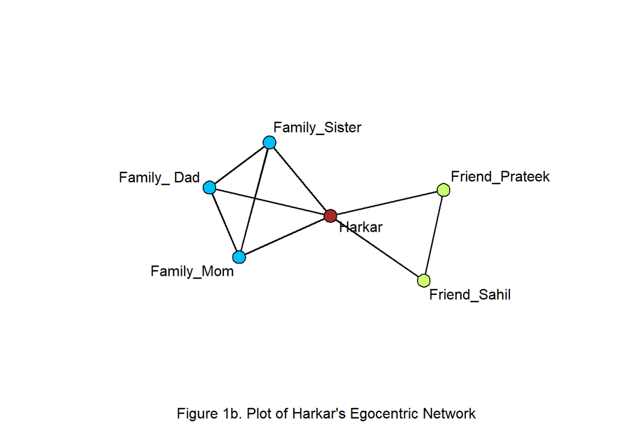

```r
# Convert into an R matrix for the purpose of our analysis
analysis.matrix <- as.matrix(csv.matrix)
# Create a network object from the matrix
egocentric.network <- network(analysis.matrix, matrix.type = "adjacency", directed = FALSE)
# Create a custom 'type' attribute for the vertices in the network
egocentric.network %v% "type" <- c("Self", "Friend", "Friend", "Family", "Family", "Family")
# Set the color for nodes of each type
vertex_colors <- rep("", network.size(egocentric.network))
for (i in 1 : length(vertex_colors)) {
    if (get.node.attr(egocentric.network, "type")[i] == "Self") {
        vertex_colors[i] <- "brown"
    } else if (get.node.attr(egocentric.network, "type")[i] == "Friend") {
        vertex_colors[i] <- "darkolivegreen1"
    } else {
        vertex_colors[i] <- "deepskyblue"
    }
}
# Plot/visualize the network
gplot(egocentric.network, gmode = "graph", label = network.vertex.names(egocentric.network), vertex.col = vertex_colors, xlab = 'Figure 1b. Plot of Harkar\'s Egocentric Network')
```

- Comment on what you see.  
  *The plot in Figure 1b. helps visualize the relations based on “free recall”, which I had recorded in the CSV file. I, being the focal actor, am connected to each of the alters. The sub-groups are represented by different colors as coded above. Relationships with the “friends” and “family” sub-groups as represented in the matrix (Figure 1a.) are depicted in the plot (Figure 1b.), with both sub-groups tied to the focal actor and no ties between the sub-groups themselves.*

#### Problem 2: Two-Mode Network Data

After loading the data for this problem set, you can use the `ls()` command to reveal the object `sw.incidence` This is the incidence matrix for the famous “Southern Women” dataset from Davis, Gardner, and Gardner’s 1941 study of class and social interaction in the Deep South[^1]. The matrix shows the attendance of 18 women at 14 informal social events during a nine-month observation period, based on various data sources such as interviews, guest lists, and participant observation. This is clearly two-mode data, with individuals as the “row vertices” and events as the “column vertices”.

##### (a) Exploring Network Data

Begin by printing the matrix, and plotting it using `plot.sociomatrix`. Who seems to be the most active? Are all the women active in the same events? Describe what you observe.

```r
print(sw.incidence)
```

```
##           E1 E2 E3 E4 E5 E6 E7 E8 E9 E10 E11 E12 E13 E14
## EVELYN     1  1  1  1  1  1  0  1  1   0   0   0   0   0
## LAURA      1  1  1  0  1  1  1  1  0   0   0   0   0   0
## THERESA    0  1  1  1  1  1  1  1  1   0   0   0   0   0
## BRENDA     1  0  1  1  1  1  1  1  0   0   0   0   0   0
## CHARLOTTE  0  0  1  1  1  0  1  0  0   0   0   0   0   0
## FRANCES    0  0  1  0  1  1  0  1  0   0   0   0   0   0
## ELEANOR    0  0  0  0  1  1  1  1  0   0   0   0   0   0
## PEARL      0  0  0  0  0  1  0  1  1   0   0   0   0   0
## RUTH       0  0  0  0  1  0  1  1  1   0   0   0   0   0
## VERNE      0  0  0  0  0  0  1  1  1   0   0   1   0   0
## MYRNA      0  0  0  0  0  0  0  1  1   1   0   1   0   0
## KATHERINE  0  0  0  0  0  0  0  1  1   1   0   1   1   1
## SYLVIA     0  0  0  0  0  0  1  1  1   1   0   1   1   1
## NORA       0  0  0  0  0  1  1  0  1   1   1   1   1   1
## HELEN      0  0  0  0  0  0  1  1  0   1   1   1   1   1
## DOROTHY    0  0  0  0  0  0  0  1  1   1   0   1   0   0
## OLIVIA     0  0  0  0  0  0  0  0  1   0   1   0   0   0
## FLORA      0  0  0  0  0  0  0  0  1   0   1   0   0   0
```

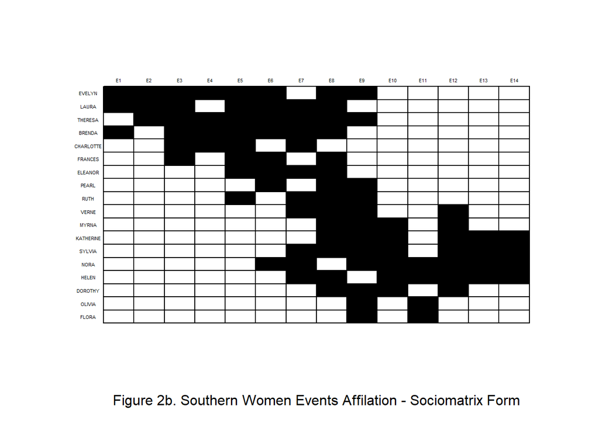

```r
plot.sociomatrix(sw.incidence, cex.lab = 0.35, xlab = 'Figure 2b. Southern Women Events Affilation - Sociomatrix Form')
```

*As per Figure 2a, 2b, Evelyn, Theresa and Nora seem to be the most active women, each having ties to 8 events. All women are not active in the same events, since the rows in the adjacency matrix printed above are not identical for all of them. (Olivia, Flora) and (Dorothy, Myrna) are pairs of women who are active in the same events (Figure 2b). Moreover, there seem to be almost two, although not clearly defined sub-groups of the women, which are discussed in greater detail later. Lastly, it can be observed that the event E8 has the most number of active women (14).*